# Permutation and Randomization Tests for Matched Pairs Design

The ideas developed with the Schistosomiasis example can be extended to other study designs, such as a basic two-variable design called a **matched pairs design**. In a matched pairs design, each experimental unit provides both measurements in a study with two treatments (one of which could be a control). Conversely, in the completely randomized situation of schistosomiasis K11777 treatment study, half of the units were assigned to control and half to treatment; no mouse received both treatments.

### Music and Relaxation

College students Anne Tillema and Anna Tekippe conducted an experiment to study the effect of music on a person’s level of relaxation. They hypothesized that fast songs would increase pulse rate more than slow songs. The file called `Music.csv` contains the data from their experiment. They decided to use a person’s pulse rate as an operational definition of the person’s level of relaxation and to compare pulse rates for two selections of music: a fast song and a slow song. For the fast song they chose [“Beyond This Twilight”] (http://www.youtube.com/watch?v=_XT9RO1emjo) by Nine Inch Nails, and for the slow song they chose Rachmaninoff’s [“Vocalise”](http://www.youtube.com/watch?v=h7UZhorAki4). They recruited 28 student subjects for the experiment.

Anne and Anna came up with a **matched pairs design**. Their fundamental question involved two treatments: (1) listening to the fast song and (2) listening to the slow song. They could have randomly allocated 14 subjects to hear the fast song and 14 subjects to hear the slow song, but their more efficient approach was to have each subject provide both measurements. That is, each subject listened to both songs, giving rise to two data values for each subject, called a matched pairs. Randomization came into play when it was decided by a coin flip whether each subject would listen first to the fast song or the slow song.

In experiments, units are **randomly allocated to groups** which allows researchers to make statements about causation. In this example, Anne and Anna **randomize the order** to prescribe two conditions on a single subject.

Specifically, as determined by coin flips, half the subjects experienced the following procedure:

[one minute rest; measure pulse (prepulse)] $\Rightarrow$ [listen to fast song for 2 minutes; measure pulse for second minute (fast song pulse)] $\Rightarrow$ [rest for one minute] $\Rightarrow$ [listen to slow song for 2 minutes; measure pulse for second minute (slow song pulse)].

The other half of the subjects experienced the procedure the same way except that they heard the slow song first and the fast song second as shown below.

[one minute rest; measure pulse (prepulse)] $\Rightarrow$ [listen to slow song for 2 minutes; measure pulse for second minute (slow song pulse)] $\Rightarrow$ [rest for one minute] $\Rightarrow$ [listen to fast song for 2 minutes; measure pulse for second minute (fast song pulse)].

Each subject gives us two measurements of interest for analysis: (1) fast song minus prepulse and (2) slow song pulse minus prepulse. In the `Music.csv` file, these two measurements are called `Fastdiff` and `Slowdiff`, respectively.

The graph below shows a dotplot of the 28 `Fastdiff`-minus`Slowdiff` values. Notice that positive numbers predominate and the mean difference is 1.857 beats per minute, both suggesting that the fast song does indeed heighten response (pulse rate) more than the slow song. We need to confirm this suspicion with a randomization test.

```r
Music <- read.csv('https://raw.githubusercontent.com/alanarnholt/STT3850/gh-pages/DataCSV/Music.csv')
head(Music)
```

```
##   Prepulse Slowsong Fastsong Favmusic Slowdiff Fastdiff
## 1       72       78       80        1        6        8
## 2       66       66       69        3        0        3
## 3       70       86       78        3       16        8
## 4       58       63       59        2        5        1
## 5       65       80       74        3       15        9
## 6       62       61       63        2       -1        1
##   Fastdiff_Minus_Slowdiff
## 1                       2
## 2                       3
## 3                      -8
## 4                      -4
## 5                      -6
## 6                       2
```

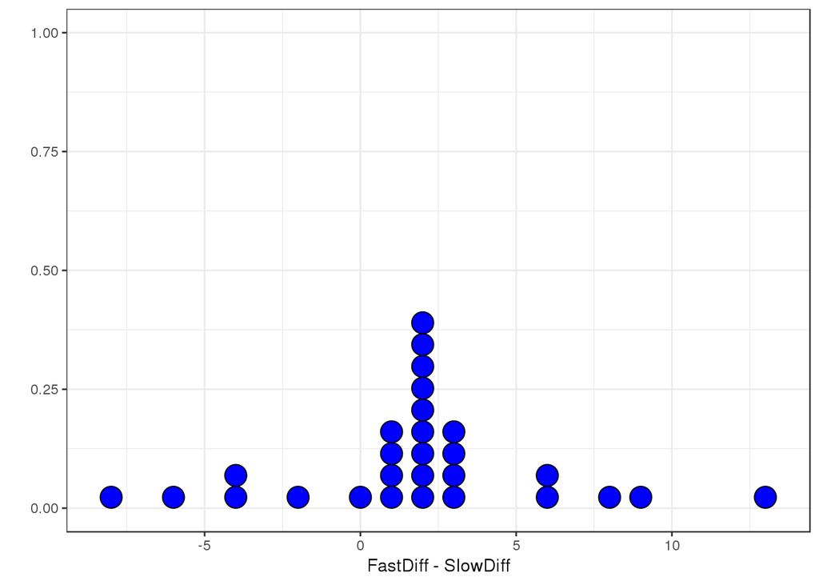

```r
require(ggplot2)
ggplot(data = Music, aes(x = Fastdiff_Minus_Slowdiff)) +
  geom_dotplot(fill = "blue") +
  theme_bw() + labs(x = "FastDiff - SlowDiff", y = "")
```

To perform a randomization test, we mimic the randomization procedure of the study design. Here, the randomization determined the order in which the subject heard the songs, so randomization is applied to the two measurements of interest for each subject. To compute a *p*-value, we determine how frequently we would obtain an observed difference as large or larger than 1.857.